# Homework

This homework recaps what you learnt in class today.

You’ll be looking at the backpack dataset contained within the CodeClanData package using tidyverse. You’ll need to load the appropriate packages first.

In all plots you make, ensure your labels are appropriate. You also must write down a short summary of what each plot tells you in order to meet MVP.

Make sure you create a new project in which to do this homework! 2 MVP

```r
library(CodeClanData)
library(tidyverse)
```

Question 1.

Load in the libraries you need, and look at the backpack data. Take note of variable names and dimensions.

```r
backpack
```

| backpack_weight | body_weight | ratio | back_problems | major | year | sex | status | units |
| --- | --- | --- | --- | --- | --- | --- | --- | --- |
| 9 | 125 | 0.0720000 | 1 | Bio | 3 | Female | U | 13 |
| 8 | 195 | 0.0410256 | 0 | Philosophy | 5 | Male | U | 12 |
| 10 | 120 | 0.0833333 | 1 | GRC | 4 | Female | U | 14 |
| 6 | 155 | 0.0387097 | 0 | CSC | 6 | Male | G | 0 |
| 8 | 180 | 0.0444444 | 0 | EE | 2 | Female | U | 14 |
| 5 | 240 | 0.0208333 | 0 | History | 0 | Male | G | 0 |
| 8 | 170 | 0.0470588 | 0 | CM | 3 | Male | U | 15 |
| 4 | 185 | 0.0216216 | 1 | ARCE | 5 | Female | U | 18 |
| 5 | 130 | 0.0384615 | 0 | Bio | 4 | Female | U | 14 |
| 2 | 120 | 0.0166667 | 0 | Bio | 5 | Female | U | 8 |

[output cut: 90 more lines]

```r
names(backpack)
```

```
[1] "backpack_weight" "body_weight"     "ratio"
[4] "back_problems"   "major"           "year"
[7] "sex"             "status"          "units"
```

```r
dim(backpack)
```

```
[1] 100   9
```

Question 2.

What is the distribution of backpack weights that students are carrying? Choose an appropriate graph to show the distribution.

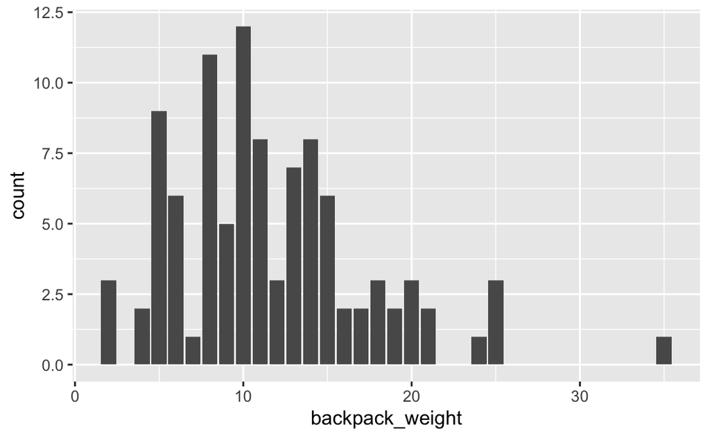

```r
backpack %>%
  ggplot() +
  geom_bar(
    aes(
      x = backpack_weight
    )
  )
```

```r
NA
NA
```

Question 3.

Are there differences in backpack weight between sex?

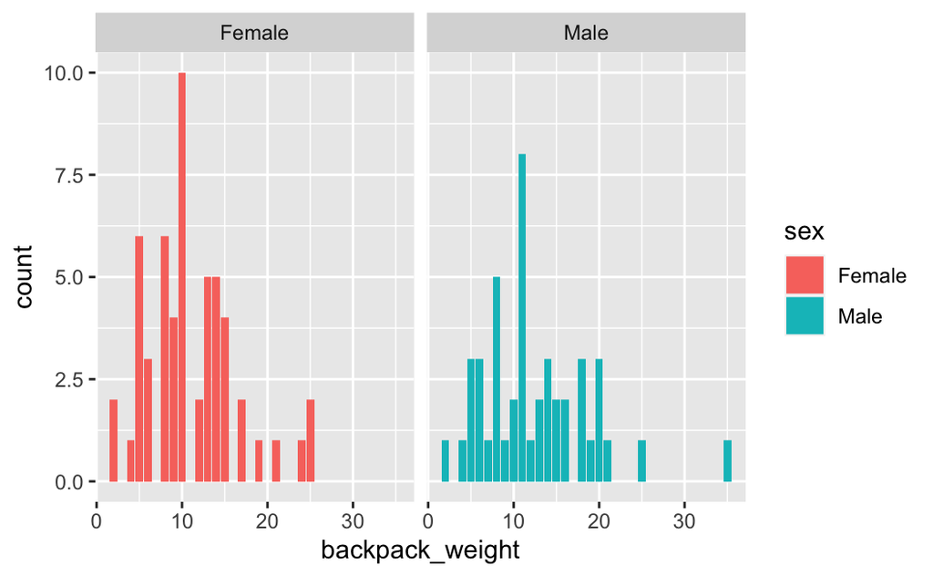

```r
backpack %>%
  ggplot() +
  geom_bar(
    aes(
      x = backpack_weight,
      fill = sex
    )
  ) +
  facet_wrap(~ sex,)
```

Question 4.

What is the relationship between body weight and backpack weight?

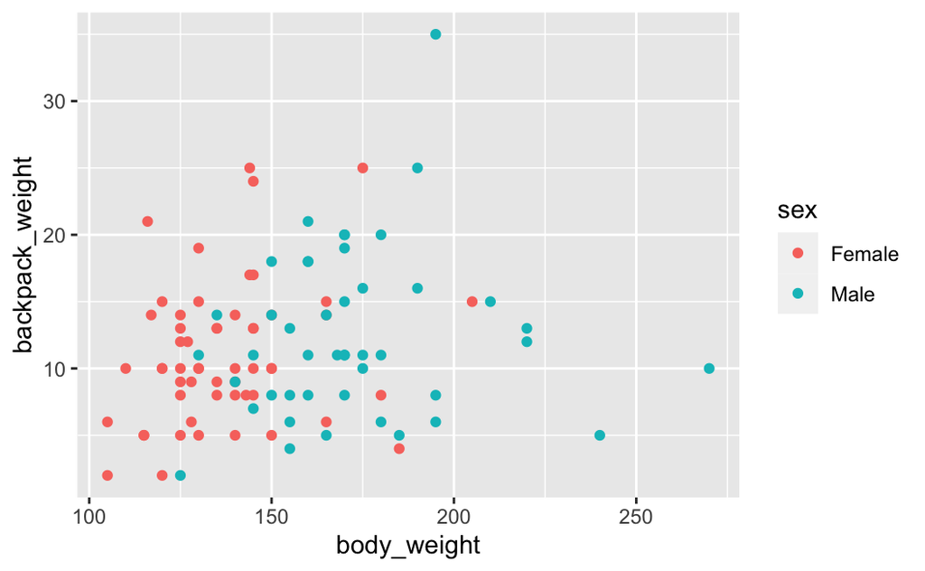

```r
backpack %>%
  ggplot() +
  geom_point(
    aes(
      x = body_weight,
      y = backpack_weight,
      colour = sex
    ))
```

```r
  # facet_wrap(~ body_weight)
```

Question 5.

Is this relationship different between men and women? Choose an appropriate plot and interpret your findings.

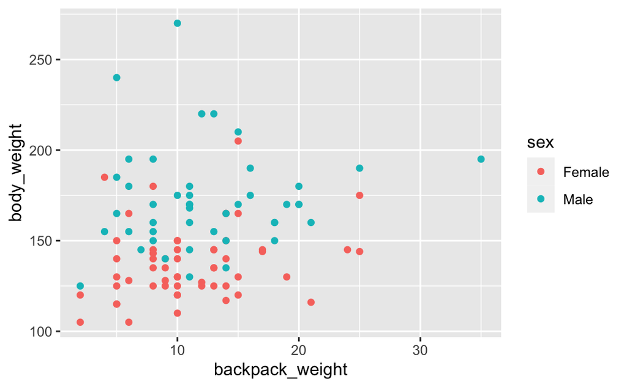

```r
backpack %>%
  ggplot() +
  geom_point(
    aes(
      x = backpack_weight,
      y = body_weight,
      colour = sex
    ))
```

```r
  # ) +
```

Question 6.

What proportion of students report back pain?

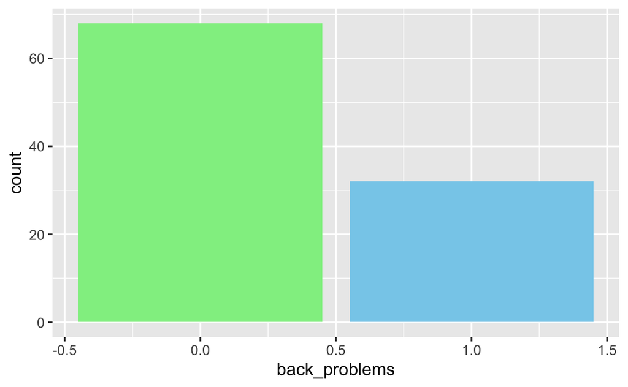

```r
backpack %>%
  ggplot() +
  geom_bar(
    aes(
      x= back_problems


    ), fill = c("light green", "sky blue")
  )
```

```r
NA
NA
```

Question 7.

Is this proportion different between men and women?

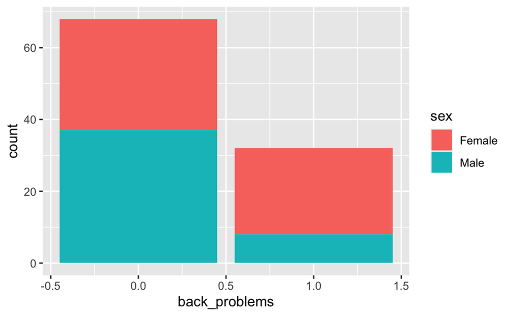

```r
backpack %>%
  ggplot() +
  geom_bar(
    aes(
      x= back_problems
      , fill = sex

    )
  )
```

Question 8.

Now you’ve investigated your data separately, create plots to describe the relationship between backpack weight, body weight, gender and reported backpain.

Try both backpack_weight and body_weight as well as the ratio.

Hint: faceting would be useful here. 3 Extensions

Question 1.

Does reported backpain differ across the year groups? Ignore year 0 in your data.

Question 2.

Is there a difference between how heavy the bags those in different years carry?